# Project Foundations for Data Science: FoodHub Data Analysis

**Marks: 60**

### Context

The number of restaurants in New York is increasing day by day. Lots of students and busy professionals rely on those restaurants due to their hectic lifestyles. Online food delivery service is a great option for them. It provides them with good food from their favorite restaurants. A food aggregator company FoodHub offers access to multiple restaurants through a single smartphone app.

The app allows the restaurants to receive a direct online order from a customer. The app assigns a delivery person from the company to pick up the order after it is confirmed by the restaurant. The delivery person then uses the map to reach the restaurant and waits for the food package. Once the food package is handed over to the delivery person, he/she confirms the pick-up in the app and travels to the customer's location to deliver the food. The delivery person confirms the drop-off in the app after delivering the food package to the customer. The customer can rate the order in the app. The food aggregator earns money by collecting a fixed margin of the delivery order from the restaurants.

### Objective

The food aggregator company has stored the data of the different orders made by the registered customers in their online portal. They want to analyze the data to get a fair idea about the demand of different restaurants which will help them in enhancing their customer experience. Suppose you are hired as a Data Scientist in this company and the Data Science team has shared some of the key questions that need to be answered. Perform the data analysis to find answers to these questions that will help the company to improve the business.

### Data Description

The data contains the different data related to a food order. The detailed data dictionary is given below.

### Data Dictionary

- order_id: Unique ID of the order
- customer_id: ID of the customer who ordered the food
- restaurant_name: Name of the restaurant
- cuisine_type: Cuisine ordered by the customer
- cost: Cost of the order
- day_of_the_week: Indicates whether the order is placed on a weekday or weekend (The weekday is from Monday to Friday and the weekend is Saturday and Sunday)
- rating: Rating given by the customer out of 5
- food_preparation_time: Time (in minutes) taken by the restaurant to prepare the food. This is calculated by taking the difference between the timestamps of the restaurant's order confirmation and the delivery person's pick-up confirmation.
- delivery_time: Time (in minutes) taken by the delivery person to deliver the food package. This is calculated by taking the difference between the timestamps of the delivery person's pick-up confirmation and drop-off information

### Let us start by importing the required libraries

```python
# import libraries for data manipulation
import numpy as np
import pandas as pd

# import libraries for data visualization
import matplotlib.pyplot as plt
import seaborn as sns
tab10 = plt.get_cmap('tab10')
sns.set_palette(tab10.colors)
def histogram_boxplot(feature, figsize=(8, 3), bins="auto"):
    """ Boxplot and histogram combined
    feature: 1-d feature array
    figsize: size of fig (default (10, 8))
    bins: number of bins (default "auto")
    """
    f, (ax_box, ax_hist) = plt.subplots(
        nrows=1, # Number of rows of the subplot grid
        ncols=2, # Number of columns of the subplot grid
        sharex=True,  # The X-axis will be shared among all the subplots
        gridspec_kw={"width_ratios": (.25, .75)},
        figsize=figsize
    )

    # Creating the subplots
    # Boxplot will be created and the mean value of the column will be indicated using some symbol
    sns.boxplot(x=feature, ax=ax_box, showmeans=True, color='lightcoral')

    # For histogram
    sns.histplot(x=feature, kde=True, ax=ax_hist, bins=bins)
    ax_hist.axvline(np.mean(feature), color='skyblue', linestyle='--')      # Add mean to the histogram
    ax_hist.axvline(np.median(feature), color='black', linestyle='-') # Add median to the histogram

    plt.show()
```

```python
from google.colab import drive
drive.mount('/content/drive')
```

### Understanding the structure of the data

```python
# read the data
df = pd.read_csv('/content/drive/MyDrive/foodhub_order.csv')
# returns the first 5 rows
df.head()
```

|  | order_id | customer_id | restaurant_name | cuisine_type | cost_of_the_order | day_of_the_week | rating | food_preparation_time | delivery_time |
| --- | --- | --- | --- | --- | --- | --- | --- | --- | --- |
| 0 | 1477147 | 337525 | Hangawi | Korean | 30.75 | Weekend | Not given | 25 | 20 |
| 1 | 1477685 | 358141 | Blue Ribbon Sushi Izakaya | Japanese | 12.08 | Weekend | Not given | 25 | 23 |
| 2 | 1477070 | 66393 | Cafe Habana | Mexican | 12.23 | Weekday | 5 | 23 | 28 |
| 3 | 1477334 | 106968 | Blue Ribbon Fried Chicken | American | 29.20 | Weekend | 3 | 25 | 15 |
| 4 | 1478249 | 76942 | Dirty Bird to Go | American | 11.59 | Weekday | 4 | 25 | 24 |

```python
# returns the last 5 rows
df.tail()
```

|  | order_id | customer_id | restaurant_name | cuisine_type | cost_of_the_order | day_of_the_week | rating | food_preparation_time | delivery_time |
| --- | --- | --- | --- | --- | --- | --- | --- | --- | --- |
| 1893 | 1476701 | 292602 | Chipotle Mexican Grill $1.99 Delivery | Mexican | 22.31 | Weekend | 5 | 31 | 17 |
| 1894 | 1477421 | 397537 | The Smile | American | 12.18 | Weekend | 5 | 31 | 19 |
| 1895 | 1477819 | 35309 | Blue Ribbon Sushi | Japanese | 25.22 | Weekday | Not given | 31 | 24 |
| 1896 | 1477513 | 64151 | Jack's Wife Freda | Mediterranean | 12.18 | Weekday | 5 | 23 | 31 |
| 1897 | 1478056 | 120353 | Blue Ribbon Sushi | Japanese | 19.45 | Weekend | Not given | 28 | 24 |

### **Question 1:** How many rows and columns are present in the data? [0.5 mark]

```python
# Check number of rows and columns
print("The number of rows in foodhub_order dataset are :", df.shape[0])
print("The number of columns in foodhub_order dataset are :", df.shape[1])
```

```
The number of rows in foodhub_order dataset are : 1898
The number of columns in foodhub_order dataset are : 9
```

#### Observations:

There are 1898 rows and 9 columns

### **Question 2:** What are the datatypes of the different columns in the dataset? (The info() function can be used) [0.5 mark]

```python
# Use info() to print a concise summary of the DataFrame
df.info()
```

```
<class 'pandas.core.frame.DataFrame'>
RangeIndex: 1898 entries, 0 to 1897
Data columns (total 9 columns):
 #   Column                 Non-Null Count  Dtype
---  ------                 --------------  -----
 0   order_id               1898 non-null   int64
 1   customer_id            1898 non-null   int64
 2   restaurant_name        1898 non-null   object
 3   cuisine_type           1898 non-null   object
 4   cost_of_the_order      1898 non-null   float64
 5   day_of_the_week        1898 non-null   object
 6   rating                 1898 non-null   object
 7   food_preparation_time  1898 non-null   int64
 8   delivery_time          1898 non-null   int64
dtypes: float64(1), int64(4), object(4)
memory usage: 133.6+ KB
```

#### Observations:

1. There are no null columns present in the dataset but as seen through df.head() and df.tail() there are missing ratings with values "not Given"
2. There are 4 integer columns, order_id, customer_id, food_preparation_time and delivery_time
3. there are 4 object columns restaurant_name, cuisine_type, day_of_the_week, rating

### **Question 3:** Are there any missing values in the data? If yes, treat them using an appropriate method. [1 mark]

```python
# Check for missing values
df.isnull().sum()
```

|  | 0 |
| --- | --- |
| order_id | 0 |
| customer_id | 0 |
| restaurant_name | 0 |
| cuisine_type | 0 |
| cost_of_the_order | 0 |
| day_of_the_week | 0 |
| rating | 0 |
| food_preparation_time | 0 |
| delivery_time | 0 |

**dtype:** int64

#### Observations:

There are no null values in the data

```python
#checking if there are any duplicate values
df.duplicated().sum()
```

```
0
```

### **Question 4:** Check the statistical summary of the data. What is the minimum, average, and maximum time it takes for food to be prepared once an order is placed? [2 marks]

```python
#check data statistics
df.describe().T
```

|  | count | mean | std | min | 25% | 50% | 75% | max |
| --- | --- | --- | --- | --- | --- | --- | --- | --- |
| order_id | 1898.0 | 1.477496e+06 | 548.049724 | 1476547.00 | 1477021.25 | 1477495.50 | 1.477970e+06 | 1478444.00 |
| customer_id | 1898.0 | 1.711685e+05 | 113698.139743 | 1311.00 | 77787.75 | 128600.00 | 2.705250e+05 | 405334.00 |
| cost_of_the_order | 1898.0 | 1.649885e+01 | 7.483812 | 4.47 | 12.08 | 14.14 | 2.229750e+01 | 35.41 |
| food_preparation_time | 1898.0 | 2.737197e+01 | 4.632481 | 20.00 | 23.00 | 27.00 | 3.100000e+01 | 35.00 |
| delivery_time | 1898.0 | 2.416175e+01 | 4.972637 | 15.00 | 20.00 | 25.00 | 2.800000e+01 | 33.00 |

#### Observations:

Minimum time to prepare food is 20 minutes, maximum is 35 minutes and average is 27.37 minutes

### **Question 5:** How many orders are not rated? [1 mark]

```python
unique_ratings = df["rating"].unique()
print(unique_ratings)
```

```
['Not given' '5' '3' '4']
```

```python
df_not_rated = df[(df["rating"] == "Not given")].count().reset_index(name = "count")
df_not_rated["count"].iloc[0]
```

```
736
```

#### Observations:

There are 736 orders for which ratings are "Not given" .

### Exploratory Data Analysis (EDA)

### **Question 6:** Explore all the variables and provide observations on their distributions. (Generally, histograms, boxplots, countplots, etc. are used for univariate exploration.) [9 marks]

```python
#Total number of restaurants, cuisines and whats in day of week
print("Total number of restaurant:",df["restaurant_name"].nunique())
print("Total cuisine type:", df["cuisine_type"].nunique())
print("Days in day_of_the_week column:",df["day_of_the_week"].unique())
```

```
Total number of restaurant: 178
Total cuisine type: 14
Days in day_of_the_week column: ['Weekend' 'Weekday']
```

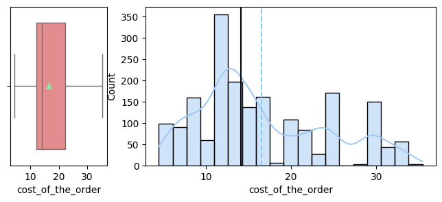

```python
histogram_boxplot(df.cost_of_the_order)
```

### Observation:

1. The distribution is slightly right skewed.High valued orders are less. Mostly customers are ordering 12-23 priced food.
2. Median price is 14
3. 75% of the orders are priced 23 or less . No outliers

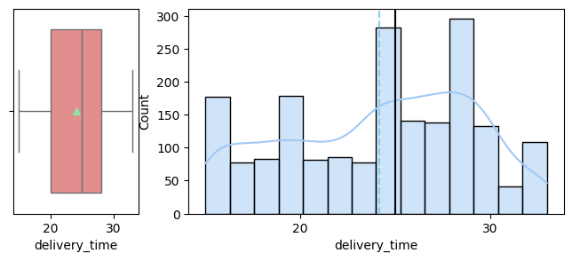

```python
histogram_boxplot(df.delivery_time)
```

#### Observation:

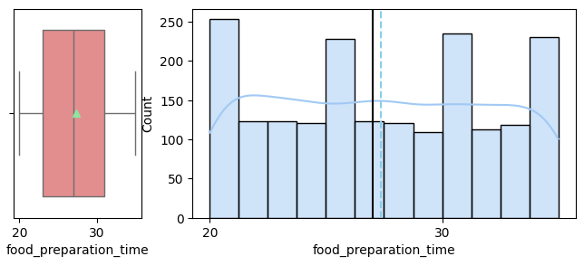

```python
histogram_boxplot(df.food_preparation_time)
```

#### Obeservation:

1. 25 % of the times order is prepared within 23 min. 75% of the orders are done in 31 minutes or under.No outliers

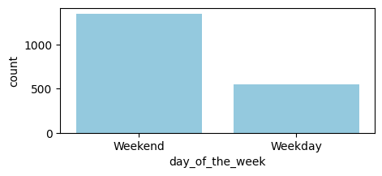

```python
#visualization of orders in days of week
plt.figure(figsize=(5, 2))
sns.countplot(data = df, x = 'day_of_the_week', color="skyblue");
plt.show()
```

#### Observation:

More number of orders are on weekends

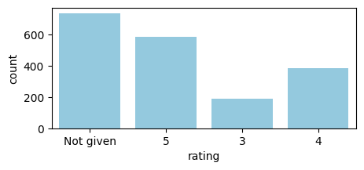

```python
#visualization of ratings
plt.figure(figsize=(5, 2))
sns.countplot(data = df, x = 'rating', color ='skyblue');
plt.show()
plt.show()
```

#### Observation:

Maximum customers have not given rating. Otherwise 5 is the next highest rating, then 4 and 3 .

### **Question 7**: Which are the top 5 restaurants in terms of the number of orders received? [1 mark]

```python
# Finding 5 restaurants with highest number of order in descending order
data_top5 = df["restaurant_name"].value_counts().sort_values(ascending=False).head(5)
print(data_top5)
```

```
restaurant_name
Shake Shack                  219
The Meatball Shop            132
Blue Ribbon Sushi            119
Blue Ribbon Fried Chicken     96
Parm                          68
Name: count, dtype: int64
```

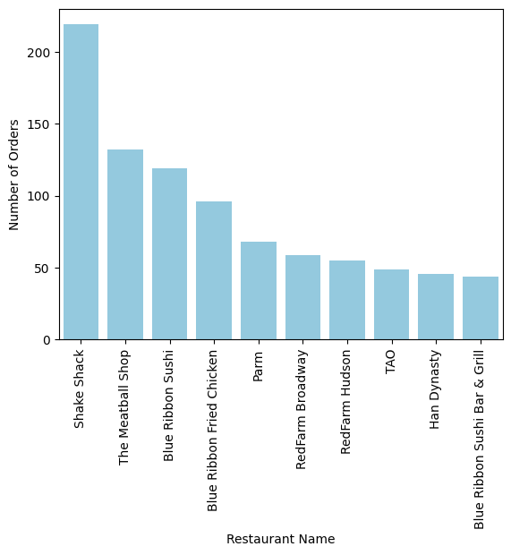

```python
#Restaurants order distribution
sns.countplot(data = df, x = 'restaurant_name', order = df['restaurant_name'].value_counts(ascending=False).head(10).index, color='skyblue')
plt.xlabel('Restaurant Name')
plt.ylabel('Number of Orders')
plt.xticks(rotation = 90)
plt.show()
```

#### Observations:

1. Shake Shack, The Meatball Shop ,Blue Ribbon Sushi , Blue Ribbon Fried Chicken and Parm are the top 5 restaurants
2. Shake Shack has highest number of orders and only 3 restaurants listed above have more than 100 orders.

### **Question 8**: Which is the most popular cuisine on weekends? [1 mark]

```python
# Most popular cuisine on weekend , used value_counts. It gives descending order count by default.
popular_cuisine = df.loc[df["day_of_the_week"] == "Weekend", "cuisine_type"].value_counts()
print(popular_cuisine)
```

```
cuisine_type
American          415
Japanese          335
Italian           207
Chinese           163
Mexican            53
Indian             49
Mediterranean      32
Middle Eastern     32
Thai               15
French             13
Korean             11
Southern           11
Spanish            11
Vietnamese          4
Name: count, dtype: int64
```

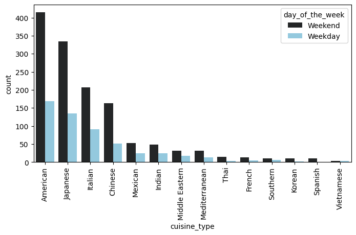

```python
#cuisine type distribution
plt.figure(figsize = (8,4))
sns.countplot(data = df, x = 'cuisine_type', order = df['cuisine_type'].value_counts().index, palette='dark:skyblue', hue= 'day_of_the_week');
plt.xticks(rotation = 90)
plt.show()
```

## Observations:

1. Most popular cuisine is American whether weekend or weekday
2. American, japanese, Italian and chinese are top 4 cuisines having most number of orders
3. Vietnamese is least popular

### **Question 9**: What percentage of the orders cost more than 20 dollars? [2marks]

```python
# Orders more than 20$
orders_above_20 = df.loc[df["cost_of_the_order"] > 20].shape[0]
total_orders = df.shape[0]
percentage_above_20 = (orders_above_20 / total_orders) * 100
print("Percentage of orders above 20$:", round(percentage_above_20, 2), "%")
```

```
Percentage of orders above 20$: 29.24 %
```

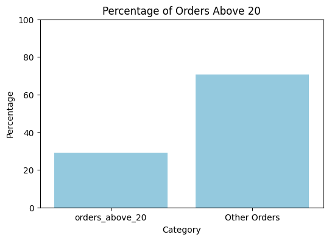

```python
data = pd.DataFrame({
    'Category': ['orders_above_20', 'Other Orders'],
    'Percentage': [percentage_above_20, 100 - percentage_above_20]
})
plt.figure(figsize=(6, 4))
sns.barplot(x='Category', y='Percentage', data=data, color='skyblue')
plt.ylabel('Percentage')
plt.title('Percentage of Orders Above 20')
plt.ylabel('Percentage')
plt.ylim(0, 100)
plt.show()
```

#### Observations:

High priced orders are very less. Only 29.24% (555 orders). So around 70% orders are valued under 20$.

### **Question 10**: What is the mean order delivery time? [1 mark]

```python
# Mean order delivery time
df["delivery_time"].mean().round(2)
```

```
24.16
```

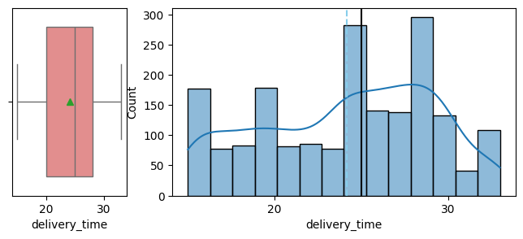

```python
histogram_boxplot(df.delivery_time)
```

#### Observations:

Mean delivery time is 24 and median is 25 which indicates left skewedness of the data. There are very few short delivery times that have affected mean value and hence it is lower than median

### **Question 11:** The company has decided to give 20% discount vouchers to the top 3 most frequent customers. Find the IDs of these customers and the number of orders they placed. [1 mark]

```python
# Write the code here
top3_freq_customers = df["customer_id"].value_counts().sort_values(ascending=False).reset_index(name = "Order Frequency").head(3)
top3_freq_customers.columns = ["Customer ID", "Order Frequency"]
print(top3_freq_customers)
```

```
   Customer ID  Order Frequency
0        52832               13
1        47440               10
2        83287                9
```

### **Question 12**: Perform a multivariate analysis to explore relationships between the important variables in the dataset. (It is a good idea to explore relations between numerical variables as well as relations between numerical and categorical variables) [10 marks]

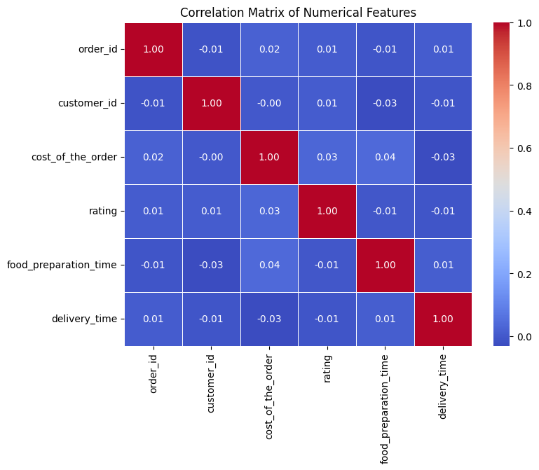

```python
# Check for correlation between numerical variables, keeping not rated ratings as NaN in dataset copy for finding correlation
df_copy = df.copy()

#Replacing not rated values with np.nan and converting the column type
df_copy['rating'] = pd.to_numeric(df_copy['rating'].replace("Not given", np.nan), errors = 'coerce')
df_copy['rating'].astype(float)
# Include only numeric type columns from the dataset
numeric_cols = df_copy.select_dtypes(include=["number"])

# Compute correlation matrix
correlation_matrix = numeric_cols.corr()
# Plot the heatmap
plt.figure(figsize=(8, 6))
sns.heatmap(correlation_matrix, annot=True, cmap="coolwarm", fmt=".2f", linewidths=0.5)
plt.title("Correlation Matrix of Numerical Features")
plt.show()
```

#### Observations:

Very weak correlation

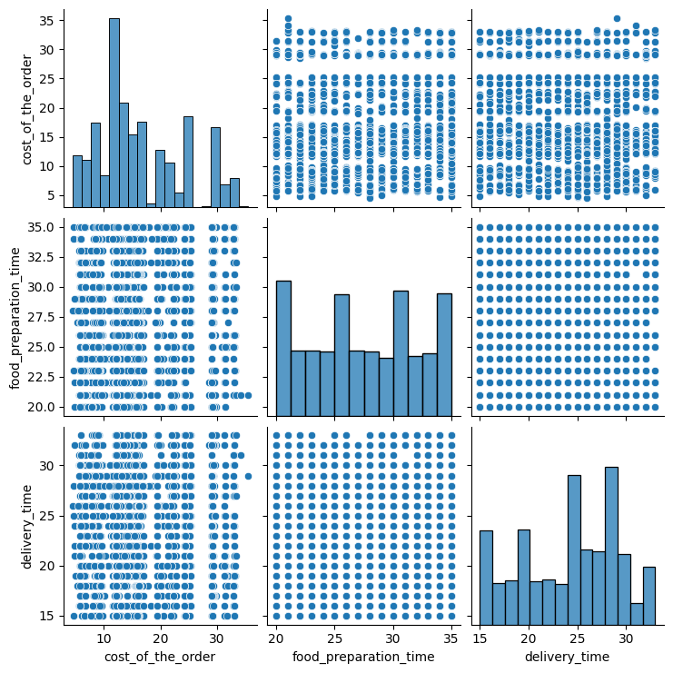

```python
#Cost of orders Vs delivery time Vs food Preparaiton time pair plotting to view relationship between continuous variables
sns.pairplot(data = df[['cost_of_the_order', 'food_preparation_time', 'delivery_time']])
```

#### Observations:

There is no linear relationship between any numeric variables

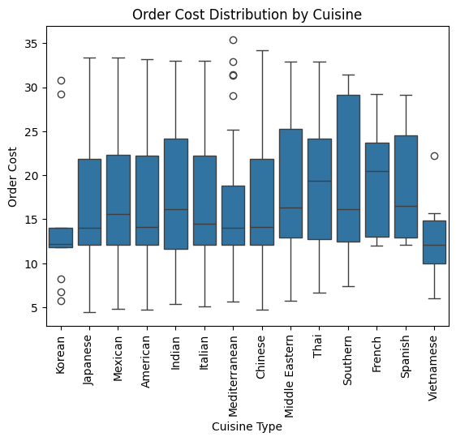

```python
#Analyzing order cost for each cuisine
sns.boxplot(x='cuisine_type', y='cost_of_the_order', data=df)
plt.xticks(rotation=90)
plt.title('Order Cost Distribution by Cuisine')
plt.xlabel('Cuisine Type')
plt.ylabel('Order Cost')
plt.show()
```

#### Observations:

1. Median order cost of mostly all cuisines falls in between 10-20
2. High IQR of southern cuisine indicate large variation of its food cost
3. There are outliers in Korean, Mediterranean and vietnamese cuisines order cost

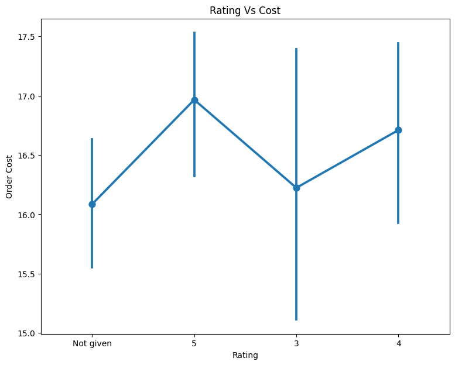

```python
plt.figure(figsize = (9, 7))
sns.pointplot(x = "rating", y = "cost_of_the_order",  data = df)
plt.title("Relationship Between Customer Ratings and Order Cost")
plt.ylabel('Order Cost')
plt.xlabel('Rating')
plt.title('Rating Vs Cost')
plt.show()
```

#### Observations:

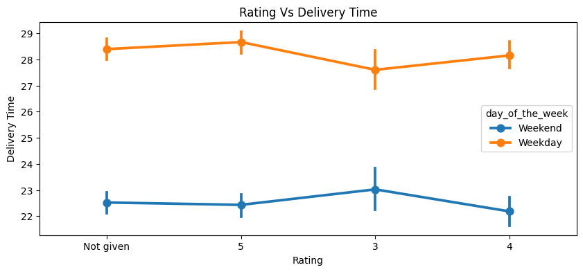

```python
# Relationship between rating and delivery time
plt.figure(figsize = (10, 4))
sns.pointplot(x = 'rating', y = 'delivery_time', hue="day_of_the_week",data = df)
plt.ylabel('Delivery Time')
plt.xlabel('Rating')
plt.title('Rating Vs Delivery Time')
plt.show()
```

#### Observations:

1. For Weekday, Rating drops to 3 with lower delivery time. This can be due to food being spoilt by accident or rush.
2. For Weekend, its exactly opposite, rating drops to 3 with higher delivery times
3. Delivery time is higher on the weekdays

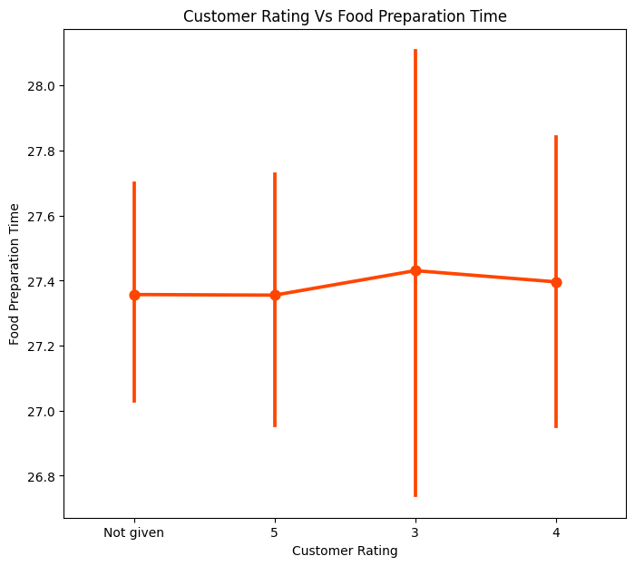

```python
# Relationship between rating and food preparation time
plt.figure(figsize=(8, 7))
sns.pointplot(x="rating", y='food_preparation_time', data=df, color="orangered")
plt.title("Customer Rating Vs Food Preparation Time")
plt.xlabel("Customer Rating")
plt.ylabel("Food Preparation Time")
plt.show()
```

#### Observations:

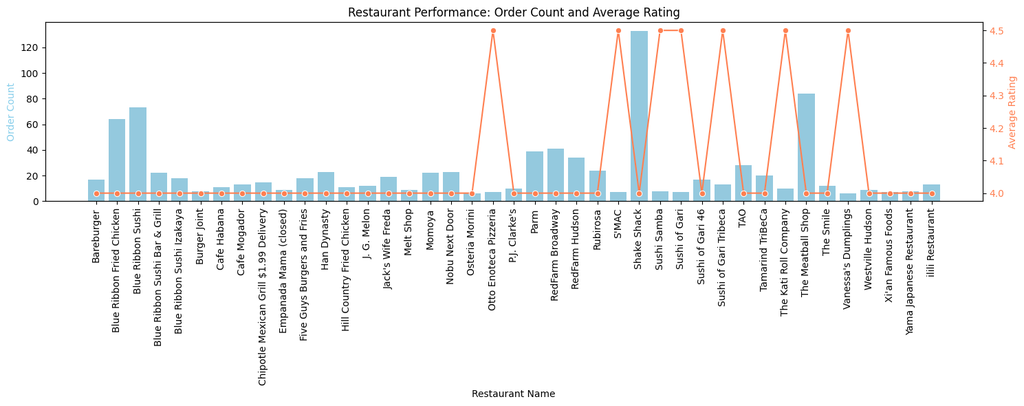

```python
#Analysing average ratings and order costs of Restaurants with order count more than 5
restaurant_with_more_orders = df_copy.groupby(['restaurant_name', 'rating'])['order_id'].count().reset_index(name='order_count')

# Filter restaurants with at least 5 orders
filtered_restaurants = restaurant_with_more_orders.groupby('restaurant_name')['order_count'].sum().reset_index()
filtered_restaurants_list = filtered_restaurants[filtered_restaurants['order_count'] > 5]['restaurant_name'].tolist()
restaurant_ratings = restaurant_with_more_orders[restaurant_with_more_orders['restaurant_name'].isin(filtered_restaurants_list)]
restaurant_ratings = restaurant_ratings.groupby(['restaurant_name']).agg({'rating': 'mean','order_count':'sum'}).reset_index()

fig, ax1 = plt.subplots(figsize=(15, 6))
# Bar plot for order count (primary y-axis)
sns.barplot(x='restaurant_name', y='order_count', data=restaurant_ratings, ax=ax1, color='skyblue')
ax1.set_xlabel('Restaurant Name')
ax1.set_ylabel('Order Count', color='skyblue')
plt.xticks(rotation=90,)

# Create secondary y-axis for average rating
ax2 = ax1.twinx()

# Line plot for average rating (secondary y-axis)
sns.lineplot(x='restaurant_name', y='rating', data=restaurant_ratings, ax=ax2, color='coral', marker='o')
ax2.set_ylabel('Average Rating', color='coral')
ax2.tick_params(axis='y', labelcolor='coral')

plt.title('Restaurant Performance: Order Count and Average Rating')
plt.tight_layout()
plt.show()
```

#### Observations:

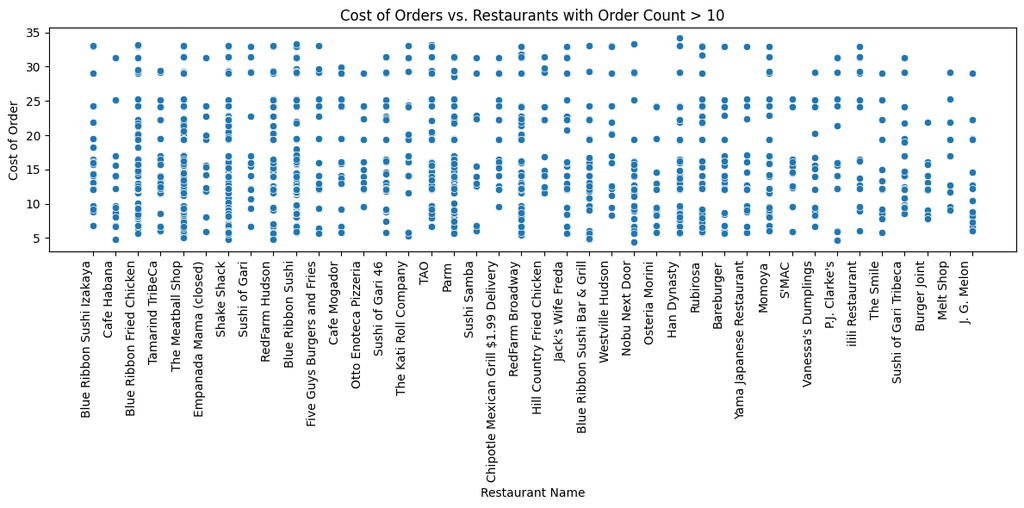

```python
#Checking maximum order price range for Restaurants (having more than 10 order counts)
restaurant_order_counts = df.groupby('restaurant_name')['order_id'].count().reset_index(name='order_count')

# Filter restaurants with order counts higher than 10
filtered_restaurants = restaurant_order_counts[restaurant_order_counts['order_count'] > 10]['restaurant_name'].tolist()

#Filter the original DataFrame to include only the selected restaurants
filtered_df = df[df['restaurant_name'].isin(filtered_restaurants)]

# Create the scatter plot
plt.figure(figsize=(12, 6))  # Adjust figure size as needed
sns.scatterplot(x='restaurant_name', y='cost_of_the_order', data=filtered_df)

plt.title("Cost of Orders vs. Restaurants with Order Count > 10")
plt.xlabel("Restaurant Name")
plt.ylabel("Cost of Order")
plt.xticks(rotation=90, ha='right')  # Rotate x-axis labels for readability
plt.tight_layout()
plt.show()
```

#### Observations:

Clearly restaurants display more orders at 5-25 price range.

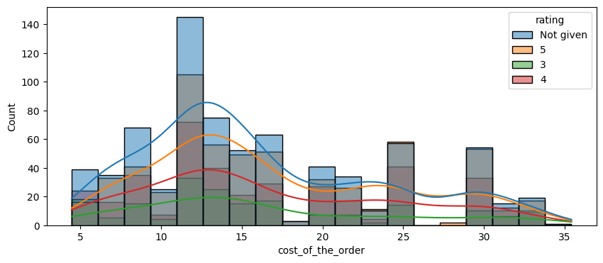

```python
#Checking maximum order price range and ratings across all orders
plt.figure(figsize = (10,4))
sns.histplot(data = df, x = 'cost_of_the_order', hue = 'rating', kde = True)
```

#### Observations:

Most orders are priced around 12-14 and they are also the ones with the most ratings provided by customers.

### Observations:

Weekday delivery time is higher, although orders on weekend are more

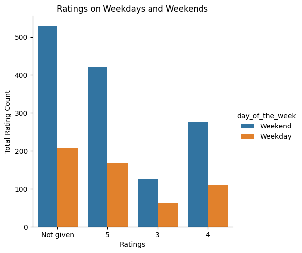

```python
sns.catplot(x='rating', hue='day_of_the_week', data=df, kind = 'count')
plt.title("Ratings on Weekdays and Weekends")
plt.xlabel("Ratings")
plt.ylabel("Total Rating Count")
plt.show()
```

#### Observations:

More ratings are given on weekend. Probably because everyone is busier during weekdays.

### **Question 13:** The company wants to provide a promotional offer in the advertisement of the restaurants. The condition to get the offer is that the restaurants must have a rating count of more than 50 and the average rating should be greater than 4. Find the restaurants fulfilling the criteria to get the promotional offer. [3 marks]

```python
# Use df_copy where ratings were converted to float
filtered_restaurants = df_copy.groupby('restaurant_name')['rating'].agg(['count', 'mean']) # Group by restaurant and calculate order count and average of ratings
filtered_restaurants = filtered_restaurants[filtered_restaurants['count'] > 50]  # Filter for order counts higher than 50
filtered_restaurants = filtered_restaurants[filtered_restaurants['mean'] > 4]  # Filter for average ratings higher than 4
filtered_restaurants = filtered_restaurants.sort_values(by='count', ascending=False)  # Sort by average rating in descending order
print(filtered_restaurants)
```

```
                           count      mean
restaurant_name
Shake Shack                  133  4.278195
The Meatball Shop             84  4.511905
Blue Ribbon Sushi             73  4.219178
Blue Ribbon Fried Chicken     64  4.328125
```

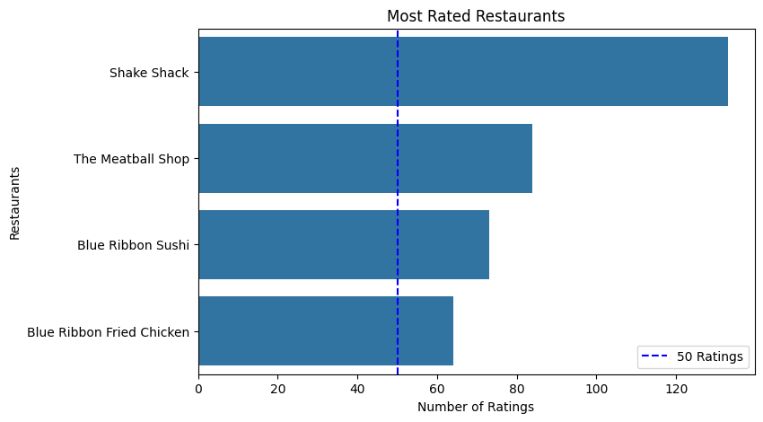

```python
# Creating a plot to show the data
figsize=(8,5)
fig, ax = plt.subplots(figsize=figsize)
sns.barplot(data=filtered_restaurants, y="restaurant_name", x="count" );
plt.axvline(x=50, color='b', linestyle='--',label="50 Ratings")
plt.title("Most Rated Restaurants")
plt.xlabel("Number of Ratings")
plt.legend()
plt.ylabel("Restaurants")
plt.show()
```

#### Observations:

1. Shake shack has highest number of ratings and meatball has highest average rating
2. Only 4 restaurants have more than 50 ratings
3. Average rating is above 4

### **Question 14:** The company charges the restaurant 25% on the orders having cost greater than 20 dollars and 15% on the orders having cost greater than 5 dollars. Find the net revenue generated by the company across all orders. [3 marks]

```python
def revenue(x):
    if x > 20:
        return x*0.25
    elif x > 5 and x<= 20:
        return x*0.15
    else:
        return 0

df_copy['Revenue'] = df_copy['cost_of_the_order'].apply(revenue)
total_net_revenue = df_copy['Revenue'].sum()
print("The total revenue of the company is:" ,round(total_net_revenue))
```

```
The total revenue of the company is: 6166
```

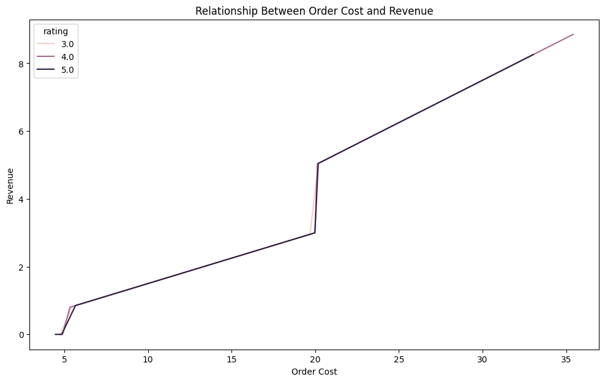

```python
# Revenue and cost of the order.
plt.figure(figsize=(12,7))
sns.lineplot(x="cost_of_the_order", y="Revenue", data=df_copy, hue = 'rating', markers=True)
plt.title("Relationship Between Order Cost and Revenue")
plt.xlabel("Order Cost")
plt.ylabel("Revenue")
plt.show()
```

#### Observations:

All lines trend upwards, indicating that as the cost of an order increases, so does the revenue generated for the company.

All rating lines are almost overlapping indicating all customers who have rated orders higher or lower show similar order spending behavior

### **Question 15:** The company wants to analyze the total time required to deliver the food. What percentage of orders take more than 60 minutes to get delivered from the time the order is placed? (The food has to be prepared and then delivered.) [2 marks]

```python
total_delivery_time = df['food_preparation_time'] + df['delivery_time']
total_delivery_time_over_60 = total_delivery_time[total_delivery_time > 60]
percentage_order_over_60 = total_delivery_time_over_60.count()/df['order_id'].count()*100
print("Percentage orders that take more than 60 minutes of total delivery time is:", "{:.2f}".format(percentage_order_over_60))
```

```
Percentage orders that take more than 60 minutes of total delivery time is: 10.54
```

#### Observations:

Only 10.5% orders take more than 60 minutes , i.e., only 200 orders out of 1898 have taken more than 60 minutes of total delivery time. This tells that motly deliveries are efficiently handled.

### **Question 16:** The company wants to analyze the delivery time of the orders on weekdays and weekends. How does the mean delivery time vary during weekdays and weekends? [2 marks]

```python
average_delivery_time = df.groupby('day_of_the_week')['delivery_time'].mean()
weekday_av = round(average_delivery_time.loc['Weekday'])
weekend_av = round(average_delivery_time.loc['Weekend'])
print("The mean delivery time on weekday is:",weekday_av )
print("The mean delivery time on weekend is:",weekend_av )
```

```
The mean delivery time on weekday is: 28
The mean delivery time on weekend is: 22
```

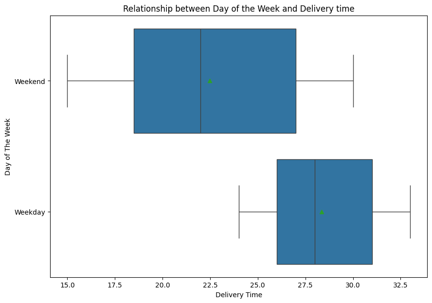

```python
# Relationship between Day of the Week and Delivery Time
plt.figure(figsize=(10,7))

sns.boxplot(y="day_of_the_week", x="delivery_time", showmeans=True,data=df)
plt.title("Relationship between Day of the Week and Delivery time")
plt.ylabel("Day of The Week")
plt.xlabel("Delivery Time")
plt.show()
```

#### Observations:

1. The average delivery time on weekday is higher than weekend,

although as we saw earlier number of deliveries/orders on weekend are higher. This can be because of lower employee force during the weekdays. 2. Average delivery time of weekend is 22.5 minutes and average delivery time on the weekdays is about 28 minutes.

### Conclusion and Recommendations

### **Question 17:** What are your conclusions from the analysis? What recommendations would you like to share to help improve the business? (You can use cuisine type and feedback ratings to drive your business recommendations.) [6 marks]

```python
#Finding oorder frequency of customers
order_frequency = df_copy.groupby('customer_id')['order_id'].count().reset_index(name='order_frequency')
orer_frequency = order_frequency.sort_values(by='order_frequency', ascending=False)
order_frequency = order_frequency.groupby('order_frequency')['customer_id'].count().reset_index(name='customer_count')

print(order_frequency)
```

```
    order_frequency  customer_count
0                 1             784
1                 2             267
2                 3              83
3                 4              33
4                 5              19
5                 6               6
6                 7               4
7                 8               1
8                 9               1
9                10               1
10               13               1
```

### Recommendations:

1. For better customer experience,it is best to have a recommendation system that projects best rated and best selling food items to clients.

One way to achieve this is to get more customer ratings and feedback.

Also, offers for repeated ordering can encourage customers to order repeatedly.

4. Foodhub needs to find out cause of high delivery times specially during weekdays and they need to reduce it. Lower delivery times increase number of ratings too.
5. FoodHub must work with new or low performing resturants to introduce more meals at price range where customers are more attracted. Offering that price range can attract more customers to these restaurants.
6. Foodhub can provide offers to high demand restaurants (which have more orders) as they serve most of the orders.
7. Very less cuisines have high order count. Foodhub should offer discounts to attract customers to the other cuisines to increase their demand.